# 推荐冷启动中粉丝转换行为的影响因素分析

### 狗熊会

案例难度：*

案例背景：伴随着移动互联网的用户数规模的增长，新闻资讯行业的月活跃用户数规模迅猛增长，从2020年的6.81亿增长到7.30亿，月平均使用时长从15.4小时增长到了17.5小时（李佳咪，2022）。用户数的快速扩大和渗透，使得新闻咨资讯行业面临的用户群体更加多样与复杂，而移动设备普及又使得平台可以更加便捷的识别获取用户信息，优化个性化推荐方式逐渐成为的平台吸引用户与广告商的重要途径。推荐系统连接了用户和内容，用户时刻都在面对着新增的内容，这些内容是没有历史信息和行为积累的，**而一个视频的质量往往需要积累一定时间才能得到较为贴切的认知，这个积累的过程就被成为冷启动**。对于新增的视频来说，如果在冷启动中没有得到足够的用户行为反馈数据，那么系统就会认为这篇内容是不受欢迎的，推荐系统会自动降低这篇内容的推荐量。类似的，如果获得了比较正面的用户行为反馈数据，那么这篇信息内容就会被推荐系统快速的扩大化推荐，获取到更多的曝光和分发流量。内容的冷启动推荐的质量，是推荐系统的内容供给的起点，他的推荐质量的好坏直接决定了该内容是否可以被更多用户看到。**因此本文基于某新闻资讯公司冷启动流量数据，聚焦于每条内容获取粉丝关注的能力，认为在冷启动过程中存在粉丝转化行为的内容更具潜力，推广它能够为平台带来更高的商业价值**。期望基于其公司内部用户与内容数据信息探索高商业价值内容的表征，优化设计冷启动推荐机制，精准识别新增的高商业价值的内容。

数据说明：本案例的因变量为`是否存在粉丝转化行为`，即在推荐系统冷启动过程中，是否存在用户因本条内容关注内容发布者，代表着该内容潜在的获取关注与收获利润的能力。在本次冷启动流量数据中30%的的内容为存在粉丝转化行为，在探索分析部分，将其细分为0，1~4，5~24，25及以上四个水平进行展示，有助于规划存在粉丝转化行为的内容内部的流量分配。如**表1 变量说明表**所示，本案例的自变量包含`内容类型`、`品类`、`原创标识`、`作者等级`、`内容质量`，均为因子型变量。`内容类型`分为图文、横版视频、竖版视频三类，视频类型的内容会在wifi情境下获得更多推荐。`品类`指内容包含的信息，分为科教、时事、影视、娱乐、生活、其它六类。在质量特征，`作者等级`基于作者过往作品表现，分为普通、优质、低质三类，`内容质量`为机器评估的得分，分为A、B、C、D四个等级。此外，综合作者声与明机器判断生成内容的`原创标识`。

表1 变量说明表

| 变量类型 | 变量名 | 详细说明 | 取值范围 |
| --- | --- | --- | --- |
| 因变量 | 是否存在粉丝转换行为 | 定性变量（2水平） | 有、无 |
| 自变量 | 内容类型 | 定性变量（3水平） | 图文、横版视频、竖版视频 |
|  | 品类 | 定性变量（6水平） | 科教、时事、影视、娱乐、生活、其它 |
|  | 内容质量 | 定性变量（4水平） | A、B、C、D |
|  | 作者等级 | 定性变量（3水平） | 低质、普通、优质 |
|  | 原创标识 | 定性变量（2水平） | 原创、非原创 |

本案例的学习目标包括：

1. 学会转换变量的数据类型和查看数据集概况。
2. 学会绘制棘状图并加以解读。
3. 构建决策树模型，并对模型做出评价。

## 准备工作

```r
# 读入需要的包
library(dplyr)
library(ggplot2)
library(gridExtra)
library(randomForest)
library(rpart)
library(rpart.plot)

# 读入数据
data = read.csv('推荐系统冷启动流量数据.csv')

# 设置作图背景参数
theme_blank = theme_bw() +
  theme(axis.text = element_text(face = "bold",size=10),
          axis.title = element_text(face = "bold",size=12),
          panel.background = element_rect(fill = "transparent"),
          panel.border=element_rect(fill='transparent',color='transparent'),
          axis.line = element_line(color = "black"),
          plot.title = element_text(hjust = 0.5))

mycol = ggsci::pal_lancet(alpha = 0.6)(9)
```

## 任务一

读入数据，查看数据分布情况。

我们显示使用factor函数将部分变量由文本型转为因子型，并通过levels参数设置因子水平的顺序。

之后通过summary函数查看数据情况。对于数值型变量，summary函数会展示其最大最小值、上下四分位数、中位数和均值；对于因子型变量，summary函数会展示各水平频数。

```r
# 对部分自变量转为因子型变量，并设置因子水平的顺序
data$作者等级 = as.factor(data$作者等级)
data$内容类型 = factor(data$内容类型,levels = c("图文","横版视频","竖版视频"))
data$品类 = as.factor(data$品类)
data$原创标识 = factor(data$原创标识)
data$内容质量 = factor(data$内容质量,levels = c("D","C","B","A"))
data$粉丝转化量 = factor(data$粉丝转化量, levels = c("0","1~4","5~24","25及以上"))
data$是否存在粉丝转化行为 = factor(data$是否存在粉丝转化行为, levels = c("无","有"))
data$品类 = factor(data$品类,levels = table(data$品类)%>%sort()%>%names())

# 查看数据
summary(data)
```

```
     文章id          作者等级        内容类型      品类        原创标识
 Min.   :3.409e+05   优质:3780   图文    :2383   其他: 320   原创  :3499
 1st Qu.:2.532e+09   低质: 187   横版视频:3815   科教: 609   非原创:4218
 Median :5.007e+09   普通:3750   竖版视频:1519   时事:1302
 Mean   :4.989e+09                               影视:1597
 3rd Qu.:7.437e+09                               娱乐:1910
 Max.   :9.999e+09                               生活:1979
 内容质量      收入            粉丝转化数         粉丝转化量
 D: 242   Min.   :       0   Min.   :   0.00   0       :5387
 C: 432   1st Qu.:     234   1st Qu.:   0.00   1~4     : 818
 B:6412   Median :    1414   Median :   0.00   5~24    : 910
 A: 631   Mean   :   24437   Mean   :  19.04   25及以上: 602
          3rd Qu.:    7859   3rd Qu.:   3.00
          Max.   :16655294   Max.   :6942.00
 是否存在粉丝转化行为
 无:5387
 有:2330
```

## 任务二

查看因变量的分布情况，并进行绘图展示。

### 因变量——粉丝转化量

如图所示，可见存在粉丝转化行为的内容少于无转化内容，存在70%的内容粉丝转化量为0。细化展示不同内容粉丝转化量的差异，发现粉丝转化量在1~4、5~24、25及以上三个水平上的内容数量相近，均大致占到数据的10%。

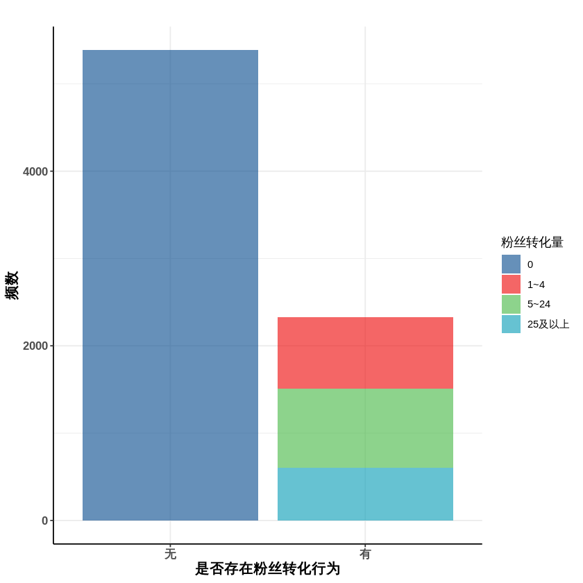

```r
ggplot(data,aes(x = 是否存在粉丝转化行为, fill = 粉丝转化量))+
  geom_bar()+
  theme_blank+
  labs(y = "频数",title = "")+
  scale_fill_manual(values = mycol[1:4])
```

## 任务三

学习当自变量与因变量同为因子型变量时，如何分析自变量对因变量的影响，并进行相应的解读。

### 自变量

#### 内容类型

在内容类型方面，竖版视频内容在粉丝转化行为上表现略优于横版视频与图文。具体观察粉丝转化量可以发现，图文内容各等级的粉丝转化量均低于视频内容。图文类型只有20%的内容存在粉丝转化行为，而其他两类视频的内容存在粉丝转化量均高于30%。此外，竖版视频中粉丝转化量在25及以上的高转换质量内容占比高，近11.2%；而横板视频、图文内容此等高转化质量内容的占比分别为8.6%、4.4%。可见该平台的粉丝更偏好视频类内容，尤其是竖版视频。

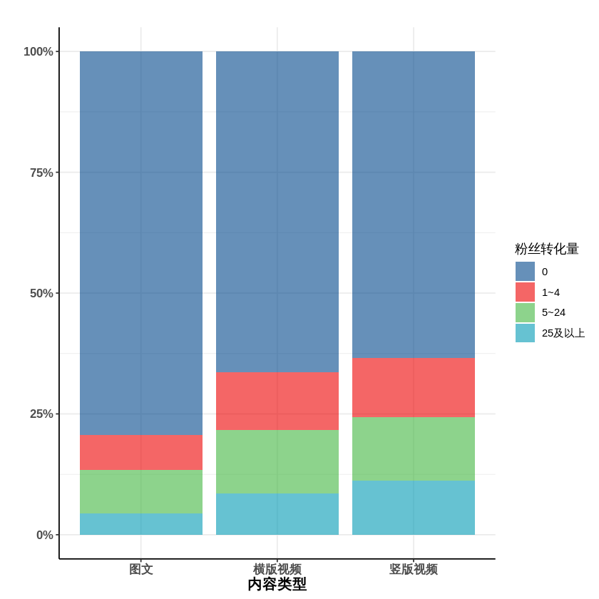

```r
ggplot(data,aes(x = 内容类型,fill = 粉丝转化量))+
  geom_bar(position = "fill")+theme_blank+
  scale_fill_manual(values = mycol[1:4])+labs(y = "",title = "")+
  scale_y_continuous(labels = scales::percent_format(accuracy = 1))+
  guides(fill = guide_legend(title = "粉丝转化量"))
```

#### 品类

观察不同品类的内容粉丝转化行为，发现娱乐类内容的表现优于其他种类，影视类略低于其他种类内容，余下四种类型内容粉丝转化量方面表现近似，即该平台上的娱乐品类的内容更具关注度。

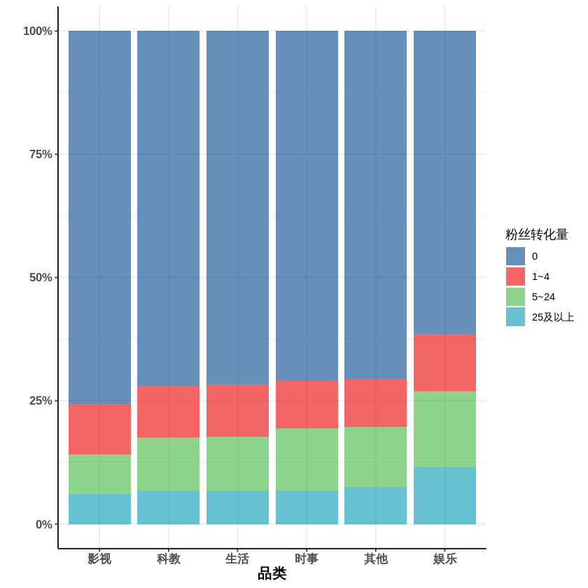

```r
ggplot(data,aes(x = reorder(`品类`,as.character(是否存在粉丝转化行为),function(x){table(x)[2]/sum(table(x))}),
                     fill = 粉丝转化量))+
  geom_bar(position = "fill")+theme_blank+
  scale_fill_manual(values = mycol[1:4])+labs(y = "",x = "品类")+
  scale_y_continuous(labels = scales::percent_format(accuracy = 1))+
  guides(fill = guide_legend(title = "粉丝转化量"))
```

#### 作者等级

棘状图上可以直观的观察到不同等级作者在粉丝转化方面的差异。优质作者40%的内容存在粉丝转化行为，远高于其他两类作者。对粉丝转化情况进行进一步细分，发现优质作者发布的内容中10.5%的内容粉丝转化量在25及以上，粉丝转换质量高。值得一提的是，图中低质作者的粉丝转化行为多于普通作者，这可能受低质作者数过少影响导致的异常，并且可以发现低质作者发布的内容粉丝转化量多为1~4个，转化质量不高。可见作者过往发布内容对其新发布内容的关注度存在影响。

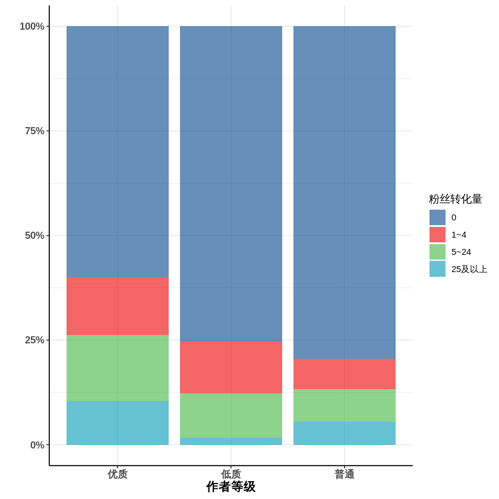

```r
ggplot(data,aes(x = 作者等级,fill = 粉丝转化量))+
  geom_bar(position = 'fill')+theme_blank+
  scale_fill_manual(values = mycol[1:4])+labs(y = "")+
  scale_y_continuous(labels = scales::percent_format(accuracy = 1))+
  guides(fill = guide_legend(title = "粉丝转化量"))
```

#### 内容质量

从棘状图看各等级内容的粉丝转化表现发现，A等级存在粉丝转化行为的内容比例达到40%，明显优于低质量视频，比其他等级内容多了10%，而其余三个等级的粉丝转化行为则十分接近。此外，B、C、D等级内容的粉丝转化质量分布也接近一致，A等级内容全方位表现更佳。可见由机器判断的内容质量具备一定参考价值。

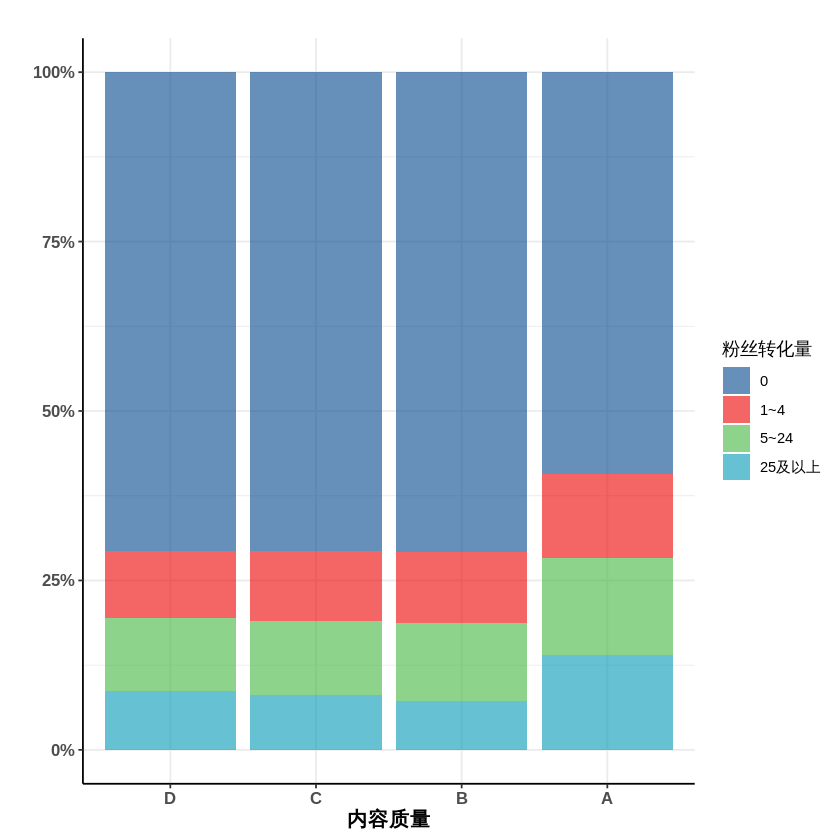

```r
ggplot(data,aes(x = 内容质量,fill = 粉丝转化量))+
  geom_bar(position = "fill")+theme_blank+
  scale_fill_manual(values = mycol[1:4])+labs(y = "",title = "")+
  scale_y_continuous(labels = scales::percent_format(accuracy = 1))+
  guides(fill = guide_legend(title = "粉丝转化量"))
```

#### 原创标识

原创内容在粉丝转化方面的表现优于非原创的内容。原创内容近有40%的内容存在粉丝转化行为，约为非原创内容的2倍。且其无论是粉丝转化量在1~24的低质量转化还是粉丝转化量在25及以上高质量转化的表现都远优于非原创内容，说明该平台上的原创内容更具的发展潜力。

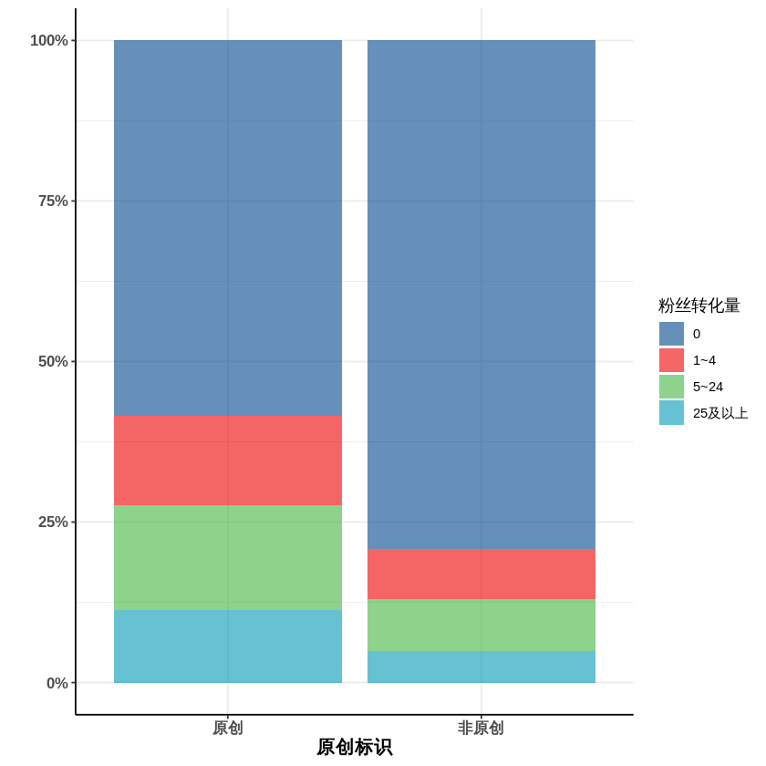

```r
ggplot(data,aes(x = 原创标识,fill = 粉丝转化量))+
  geom_bar(position = "fill")+theme_blank+
  scale_fill_manual(values = mycol[1:4])+labs(y = "")+
  scale_y_continuous(labels = scales::percent_format(accuracy = 1))+
  guides(fill = guide_legend(title = "粉丝转化量"))
```

## 任务四

建立决策树模型，查看粉丝转换的影响因素，并给出相应的解读。

### 决策树模型

```
yhat   无   有
  否 4858 1666
  是  529  664
```

```
[1] "准确率：71.56%"
```

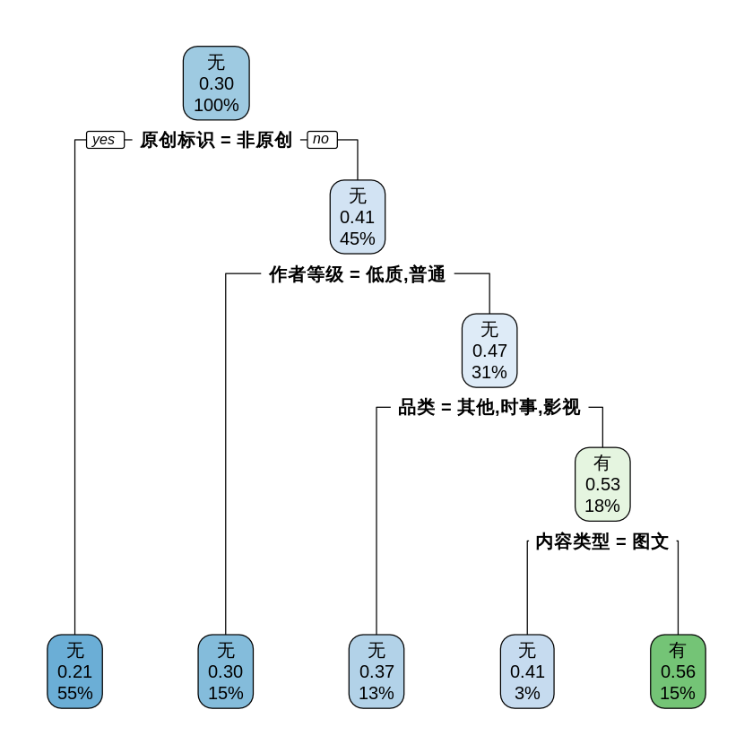

```r
# 建模
rt1 = rpart(`是否存在粉丝转化行为`~.,data[,c(2:6, 10)])
# 决策树作图
rpart.plot(rt1)


#计算出预测概率
prob = predict(rt1,data)[,2]
#以0.5为阈值
yhat = 1*(prob > 0.5)
yhat = factor(yhat,levels = c(0,1),labels = c("否","是"))
tab = table(yhat,data$是否存在粉丝转化行为)
tab
print(paste0("准确率：",(round(diag(tab)%>%sum()/sum(tab),4))*100,"%"))
```

## 结论与应用

因此对于资讯平台而言，应多推荐高等级作者的原创且内容质量好的非影视类（特别是科教、娱乐、生活类）视频（尤其是竖屏视频）。作者们若想提升自己内容获得粉丝转换的概率，应努力提升自身等级，推出原创且质量好的视频。